# Supplementary materials

Forrest W. Crawford

# Supplement: how many people inject drugs?

## Problem

Question: How many people inject drugs (e.g. opioids) in my city?

Data: counts of $m$ individuals’ emergency room visits for overdose, $X_1,\ldots,X_m$, all positive, for one unit of time (e.g. year). We only see $X_i$ if person $i$ had at least one overdose.

## Setup

Let $N$ be the number of people who inject drugs in the city.

Let $X_1,\ldots,X_N$ be the number of times (possibly zero) each has overdosed and been taken to the emergency room, in one year.

Let $M=m$ the number who have had at least one overdose. We know $X_1,\ldots,X_m > 0$

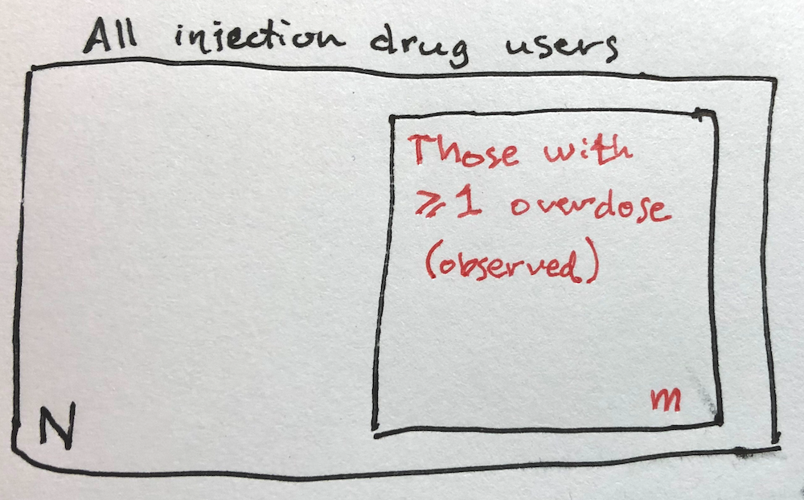

## Assumptions and their consequences

Two substantive assumptions:

1. Everyone who has had at least one overdose went to the emergency room.
2. Every drug injector has an overdose (independently of others) with constant rate $\lambda$ per year.

Then each drug injector’s overdose pattern is a Poisson process with rate $\lambda$. Since the unit of time is $t=1$ year, the number of overdoses person $i$ has in one year is distributed as

$$X_i \sim \text{Poisson}(\lambda)$$

so

$$\Pr(X_i=x) = \frac{\lambda^x e^{-\lambda}}{x!}$$

However, the hospital records only have $X_i$ when $X_i>0$. We can compute this (conditional) distribution. Recall that

$$\Pr(X_i=0) = e^{-\lambda}$$

so $\Pr(X_i>0) = 1-e^{-\lambda}$$ and by Bayes’ Theorem
$$\Pr(X_i=x|X_i>0) = \frac{\lambda^x e^{-\lambda}}{x!(1-e^{-\lambda})}$$

Since we can write the distribution of the observed data $X_1,\ldots,X_m$ in terms of $\lambda$, we can estimate $\lambda$ from the observed data.

## Estimating $\lambda$

The likelihood of $X_1,\ldots,X_m$ is the joint probability of these data, interpreted as a function of the unknown rate $\lambda$,

$$L(\lambda) = \prod_{i=1}^m \frac{\lambda^{x_i} e^{-\lambda}}{x_i!(1-e^{-\lambda})}$$

We wish to maximize $L(\lambda)$ with respect to $\lambda$.

The log-likelihood is

$$\begin{aligned}
\ell(\lambda) &\propto \sum_{i=1}^m x_i\log(\lambda) -\lambda - \log(1-e^{-\lambda})
&= \log(\lambda)\left(\sum_{i=1}^m x_i\right) -m\lambda - m\log(1-e^{-\lambda})
\end{aligned}$$
We can maximize this function with Newton’s method or any nonlinear optimization algorithm to find $\hat\lambda$.

## Estimating $N$

Because $X_i$ has Poisson distribution, we know $\Pr(X_i=0) = e^{-\lambda}$ and $\Pr(X_i>0)=1-e^{-\lambda}$ The number of drug injectors in our records is $M$, and from this we know

$$M \sim \text{Binomial}(N,1-e^{-\lambda})$$

We have an estimate $\hat\lambda$ of $\lambda$, and we know that

$$E[M] = N (1-e^{-\lambda})$$
or
$$M \approx \Pr(X_i>0) \times (\text{number at risk})$$

Therefore a natural estimator can be formed by substituting the observed value $M=m$ for $E[M]$,

$$m \approx (1-e^{-\hat\lambda}) N .$$

Rearranging, we have the estimate

$$\hat{N} = \frac{m}{1-e^{-\hat\lambda}}$$